# South Fork McKenzie River Pedigree Project Analysis Notebook

```r
require(RLDNe)
require(car)
require(DHARMa)
require(emmeans)
require(MASS)
require(effects)
require(glmmTMB)
require(lme4)
require(kableExtra)
require(gt)
require(gtsummary)
require(tidyverse)
require(magrittr)
require(countreg)
require(lmerTest)
require(lubridate)
```

# Summary

This notebook contains a log of all analyses for the 2022 South Fork McKenzie River spring Chinook salmon genetic pedigree study. Inference of the pedigree used here is conducted in a separate notebook titled “parentage_notebook” in this same repository.

This is an R notebook. The .html version of this file is a fully rendered and interactive log. To view it, save the html and open in a browse. The .rmd version can be opened within R studio. To reproduce results or edit the analysis: clone the full repository onto your local machine and open the r project in rstudio. This will provide all needed data and objects.

# Pedigrees and Cohort Rationale

This notebook relies on a pedigree of all Chinook Salmon released above Cougar Dam on the South Fork McKenzie River from 2007 - 2017 using potential offspring sampled from 2010 to 2020.

## Summary of Cohort Years

Previous reports and manuscripts evaluating the reintroduction of Chinook salmon above Cougar Dam on the South Fork McKenzie river have considered NOR salmon sampled from 2010 to 2015 as potential offspring of salmon released above Cougar Dam from 2007 - 2012.

Most Chinook salmon on the South Fork McKenzie express an age at maturity of 3 - 6 years. Therefore, previous reports (relying on 2010 - 2015 NOR returns) have inferred a pedigree for salmon released above the dam from 2007 - 2009. Results based on the pedigree of salmon released above Cougar Dam in 2010 were also provided along with the caveat that age 6 offspring were not yet evaluated and some results such as Total Lifetime Fitness and Cohort Replacement Rate were likely underestimates.

Continuing this work, we have since genotyped NOR salmon sampled on the South Fork McKenzie from 2016 to 2020, as well as salmon released above Cougar dam from 2013 to 2017. These new data allow us to complete the pedigree of salmon released above Cougar Dam in 2010, infer full pedigrees TLF for salmon released above Cougar Dam from 2011 - 2014, and partial pedigrees for salmon released above the dam from 2015 - 2017.

## Inferring Pedigrees Again

Irrevocable updates to software packages used to assign parentage (COLONY) prevent us from exactly reproducing the approach used to infer the pedigrees used in previous reports. We chose to infer all pedigrees from parent years 2007 to 2017 (offspring year 2010 - 2020) from the raw genetic data using a consistent approach rather than simply combining previous pedigrees with those inferred from new data.

This approach has several advantages:  
(1) Trends - Results based on the pedigrees such as Cohort Replacement Rate and Total Lifetime Fitness suffer from the same biases across all years, allowing more confidence in the identification of year - year trends.  
(2) Fitness modeling - Similar to above, applying a consistent approach to pedigree inference gives us more power to identify predictors of fitness by allowing us to combine data from more years into a single analysis  
(3) Grandparentage and Great-Grandparentage: If a unified filtering and pedigree inference approach is used for the entire dataset, we can more confidently combine pedigrees inferred for a single offspring year with one another, allowing for a 3 (or perhaps even 4) generation pedigree. This means we can identify gradnparentage and great grandparentage, opening up the potential to address many important questions such as fitness effects of hatchery selection.  
(4) Minor Issues - In reproducing previous results, minor errors in code were identified. While these errors ultimately are expected to have little effect on the final pedigrees and results, inferring the pedigrees again allows us to fix these small errors and evaluate their effects. For example in the Cervus pedigrees, the software is run using a single parent year and a single offspring year, then the results are concatenated for all parent years within an offspring year. This renders the likelihoods incomparable. Likelihoods are used to break ties when inferring the cervus pedigree, but it likely never had a large effect because Colony is given priority in the consensus pedigree.

Throughout the notebook we present the results for all parent years using the newly inferred pedigrees.

# Goals

1. Summarise dataset and release history
2. Summarise assignment of offspring to parents, use to infer age structure.
3. Estimate total lifetime fitness (TLF) for parent cohorts
4. Estimate cohort replacement rates for parent cohorts
5. Assess variables that influence fitness with general linear models
6. Estimate effective number of breeders using NeEstimator
7. Compare HOR and NOR fitness

This is an R notebook. The .html version of this file is a fully rendered and interactive log. To view it, save the html and open in a browse. The .rmd version can be opened within R studio. To reproduce results or edit the analysis: clone the full repository onto tyour local machine and open the r project in rstudio. This will provide all needed data and objects.

# Data

**Genotype and Metadata**  
A log of the work to consolidate sample metadata can be found in the *cougar_trap_metadata_mgmt* and the *meta_data_consolidation* R notebooks in the metadata directory of this repository. There are also readmes in that directory that explain subdirectory structure and files.

The log (R notebook) for genotype data prep is titled *genotype_data_prep* and can be found in the genotypes directory of this repository.

Here, we import the final outputs of this notebook containing both sample metadata and genotype which include (by R environment name):

1. **full_unfilt:** All genotypes and metadata, no genotype quality filtering. Includes all individuals known to be potential parents or offspring for the project.
2. **full_data_1.0:** Genotypes and metadata, after removing individuals with fewer than 7 scored genotypes and removing duplicates.

```r
load("../genotypes/genotype_data/full_unfiltered_dataset.R")
load("../genotypes/genotype_data/full_filtered_dataset.R")
```

Both files also contain some individuals twice (for example: Cougar trap LSDR samples have two rows, one for each observation at the Cougar Trap). So, let’s also produce some objects that only include the final observations for individuals.

3. **dedup_unfilt:** same as full_unfilt above, but only last observation of an individual retained.
4. **dedup:** same as full_data_1.0 above, but only second observation of an individual retained.

```r
dedup <- full_data_1.0 %>%
  group_by(sample_id) %>%
  slice_max(date, with_ties = FALSE) %>%
  ungroup()

dedup_unfilt <- full_unfilt %>%
  group_by(sample_id) %>%
  slice_max(date, with_ties = FALSE) %>%
  ungroup()
```

**Pedigree**

The log for inferring final consensus pedigree can be found in the *parentage_notebook* in the parentage directory of this repository. It includes parentages for all potential offspring sampled from 2010 - 2020.

Here we import the final consensus pedigree. Note that this pedigree only has rows for assigned parentages, offspring with no parentage assigned do not appear in this object.

```r
load("../parentage/pedigree.R")
```

# Dataset and Release Summary Counts

Let’s summarise the complete dataset, by source and origin, without respect to where the fish wound up.

```r
kable(dedup %>% count(year, type, origin, section) %>%
  pivot_wider(id_cols = year, names_from = c(type, origin, section), values_from = n, names_sep = "\n"), caption = "Table N0: sample sizes by source", align = "c") %>%
  kable_classic(full_width = T, html_font = "Arial" )
```

Table N0: sample sizes by source

| year | hatchery_outplant HOR NA | cougar_trap HOR NA | cougar_trap NOR NA | sgs NOR SFMK_below | cougar_trap NA NA | precocial_male NOR NA | sgs NOR SFMK_above |
| --- | --- | --- | --- | --- | --- | --- | --- |
| 2007 | 745 | NA | NA | NA | NA | NA | NA |
| 2008 | 873 | NA | NA | NA | NA | NA | NA |
| 2009 | 1383 | NA | NA | NA | NA | NA | NA |
| 2010 | 496 | 30 | 221 | NA | NA | NA | NA |
| 2011 | 340 | 29 | 356 | 45 | NA | NA | NA |
| 2012 | 430 | 17 | 500 | 10 | NA | NA | NA |
| 2013 | 440 | 22 | 223 | 5 | NA | NA | NA |
| 2014 | 486 | 21 | 191 | 14 | 1 | 12 | 1 |
| 2015 | 600 | 19 | 241 | 24 | NA | NA | NA |
| 2016 | 459 | 74 | 295 | 31 | 4 | NA | 4 |
| 2017 | 448 | 6 | 239 | 13 | 1 | NA | NA |
| 2018 | NA | NA | 120 | 35 | NA | NA | NA |
| 2019 | NA | NA | 158 | 15 | NA | NA | NA |
| 2020 | NA | NA | 162 | NA | NA | NA | NA |

**Table N0:** Sample sizes after filtering by year, origin and source. Source column names refer to three values, separated by spaces: (1) where was the sample originally encountered (hatchery, cougar trap, during a spawning ground survey, or as a precocial male), (2) origin, and (3) for SGS samples only, was the SGS conducted above or below Cougar Dam

## Parents

### Counts and Sex Ratios

Throughout this report (and previous reports), it has been useful to split the dataset up and present results by offspring and candidate parents. Let’s keep with this approach and present the numbers of potential parents (**table N1**) and the numbers of potential offspring **table N7** .

Here we only present the numbers for final filtered dataset for two reasons:

1. In later analyses where we calculate demographic parameters such as CRR, we define the number of candidate parents as the number of potential parents passed to Colony or Cervus, to which we assign potential offspring. Keeping this consistent will make these tables less confusing down the road.
2. Duplicates: There are many individuals filtered from the raw dataset because they have identical genotypes to another sample. This is potentially due to tissue samples being stored in a shared container (one fin clip gets split into multiple pieces), or spawning ground surveys sampling the same individual that was already sampled at the Cougar Trap. Including these individuals in the number of parents is misleading.

```r
#unfilt_parent_summary <- dedup_unfilt %>%
#  filter(cand_parent == TRUE) %>%
#  count(year, type, origin) %>%
#  rename(n_unfiltered = n)

# let's add a column for sex ratio

filt_parent_summary <- dedup %>%
  filter(cand_parent == TRUE) %>%
  count(year, type, origin) %>%
  rename(n_final = n)

filt_parent_summary %<>%
  unite("type_origin", type, origin) %>%
  pivot_wider(id_cols = year, names_from = type_origin, values_from = n_final)

options(knitr.kable.NA = '')
kable(filt_parent_summary, caption = "Table N1: Number of Candidate Parents") %>%
  kable_classic(full_width = T, html_font = "Arial" )
```

Table N1: Number of Candidate Parents

| year | hatchery_outplant_HOR | cougar_trap_HOR | cougar_trap_NOR | cougar_trap_NA | precocial_male_NOR | sgs_NOR |
| --- | --- | --- | --- | --- | --- | --- |
| 2007 | 745 |  |  |  |  |  |
| 2008 | 873 |  |  |  |  |  |
| 2009 | 1383 |  |  |  |  |  |
| 2010 | 496 | 30 | 221 |  |  |  |
| 2011 | 340 | 29 | 356 |  |  |  |
| 2012 | 430 | 17 | 500 |  |  |  |
| 2013 | 440 | 15 | 172 |  |  |  |
| 2014 | 486 | 20 | 132 | 1 | 12 | 1 |
| 2015 | 600 | 19 | 135 |  |  |  |
| 2016 | 459 | 70 | 171 | 1 |  | 4 |
| 2017 | 448 | 5 | 151 | 1 |  |  |
| 2018 |  |  | 68 |  |  |  |
| 2019 |  |  | 65 |  |  |  |
| 2020 |  |  | 89 |  |  |  |

```r
# there are two
```

**Table N1:** Number of individuals relased above Cougar dam retained in the final filtered dataset. These values correspond to candidate parents used in the assignments. “Hatchery Outplant HOR” refers to individuals trapped at either McKenzie or Leaburg hatchery and released above the dam, all are HOR. Cougar Trap includes both NOR, HOR and unknown origin (NA) individuals released above the dam. Precocial males refers to a small set of jacks sampled on the spawning grounds above the dam in 2014. SGS refers to additional individuals sampled during spawning ground surveys above the dam.

Let’s also split up the parent cohorts by sex. Here we split into different tables to make them more manageable.

```r
kable(dedup %>%
  filter( cand_parent == TRUE, year < 2018) %>%
  count(year, sex) %>%
  pivot_wider(id_cols = year, names_from = sex, values_from = n) %>%
  mutate(sex_ratio = M/`F`), caption = "Table N2: Sex Ratios of all Candidate Parents", align = "c", digits = 2 ) %>%
  kable_classic(full_width = F, html_font = "Arial")
```

Table N2: Sex Ratios of all Candidate Parents

| year | F | M | sex_ratio |
| --- | --- | --- | --- |
| 2007 | 318 | 427 | 1.34 |
| 2008 | 288 | 585 | 2.03 |
| 2009 | 603 | 780 | 1.29 |
| 2010 | 263 | 484 | 1.84 |
| 2011 | 320 | 405 | 1.27 |
| 2012 | 439 | 508 | 1.16 |
| 2013 | 325 | 302 | 0.93 |
| 2014 | 386 | 266 | 0.69 |
| 2015 | 465 | 289 | 0.62 |
| 2016 | 403 | 302 | 0.75 |
| 2017 | 370 | 235 | 0.64 |

```r
kable(dedup %>%
  filter(type == "hatchery_outplant", cand_parent == TRUE) %>%
  count(year, sex) %>%
  pivot_wider(id_cols = year, names_from = sex, values_from = n) %>%
  mutate(sex_ratio = M/`F`), caption = "Table N3: Sex Ratios of Candidate Parents from Hatchery", align = "c", digits = 2) %>%
  kable_classic(full_width = F, html_font = "Arial"  )
```

Table N3: Sex Ratios of Candidate Parents from Hatchery

| year | F | M | sex_ratio |
| --- | --- | --- | --- |
| 2007 | 318 | 427 | 1.34 |
| 2008 | 288 | 585 | 2.03 |
| 2009 | 603 | 780 | 1.29 |
| 2010 | 201 | 295 | 1.47 |
| 2011 | 170 | 170 | 1.00 |
| 2012 | 248 | 182 | 0.73 |
| 2013 | 239 | 201 | 0.84 |
| 2014 | 327 | 159 | 0.49 |
| 2015 | 412 | 188 | 0.46 |
| 2016 | 315 | 144 | 0.46 |
| 2017 | 325 | 123 | 0.38 |

```r
kable(dedup %>%
  filter(type == "cougar_trap", cand_parent == TRUE, year < 2018) %>%
  count(year, sex) %>%
  pivot_wider(id_cols = year, names_from = sex, values_from = n) %>%
  mutate(sex_ratio = M/`F`), caption = "Table N4: Sex Ratios of Candidate Parents from Cougar Trap", align = "c", digits = 2) %>%
  kable_classic(full_width = F, html_font = "Arial"  )
```

Table N4: Sex Ratios of Candidate Parents from Cougar Trap

| year | F | M | sex_ratio |
| --- | --- | --- | --- |
| 2010 | 62 | 189 | 3.05 |
| 2011 | 150 | 235 | 1.57 |
| 2012 | 191 | 326 | 1.71 |
| 2013 | 86 | 101 | 1.17 |
| 2014 | 59 | 94 | 1.59 |
| 2015 | 53 | 101 | 1.91 |
| 2016 | 86 | 156 | 1.81 |
| 2017 | 45 | 112 | 2.49 |

**Tables N3 - N4:** Number of candidate parents females (F) and males (M) (individual released above Cougar Dam and retained in the final dataset). Here we split by source, individuals are either from Cougar Trap (NOR and HOR) or from the hatchery (HOR). Sex ratio is presented as n_male/n_female.

### Cougar Trap LSDR / Recycling

Finally, let’s summarise the approaches used for releasing individuals from the Cougar Trap.

Some terms to define:  
(1) **Late-season downstream release (LSDR):** Individuals that arrive at the Cougar Trap on and after September 1st are double floy tagged and released downstream at Forest Glen. If they return to the trap a second time, they are released above the dam.  
(2) **Recycling**: All individuals at the Cougar Trap, regardless of date, are first released downstream of the dam (either in Forest Glen, or just the dam tailrace). If they return a secodn time they are released above the dam.

**LDSR / Recycling Summary** During 2010, 2011 and 2012, neither LSDR or recycling was used. All fish that were trapped and survived were released above the dam.  
During 2013 and 2014, the LSDR approach was applied to NOR fish after September 1st. Some HORs on and after September 1st were also LSDR but not all.  
From 2015 onwards all NOR are recycled. Some HOR are also recycled, but most are not.

Let’s collect some numbers here.

```r
kable(full_data_1.0 %>%
  filter(type == "cougar_trap", origin == "NOR", year %in% c(2013, 2014)) %>%
    filter(date %within% interval(ymd("2013-09-01"), ymd("2013-12-01")) |  date %within% interval(ymd("2014-09-01"), ymd("2014-12-01"))) %>%
  count(year, recapture) %>%
  pivot_wider(id_cols = year, names_from = recapture, values_from = n) %>%
  mutate("percent recaptured" = (RE/NEW)*100) %>%
  rename("n new" = NEW, "n recaptured" = RE)  , digits = 1, caption = "Table N5: LSDR Program Summary", align = "c") %>%
  kable_classic(full_width = F, html_font = "Arial" )
```

Table N5: LSDR Program Summary

| year | n new | n recaptured | percent recaptured |
| --- | --- | --- | --- |
| 2013 | 64 | 15 | 23.4 |
| 2014 | 75 | 16 | 21.3 |

**Table N5**: LSDR summary: Number of NOR fish sampled at Cougar trap on or after September 1st (n new), and the number of these fish that returned a second time.  
*note: Banks 2016 tech report states that 74 (not 75 as presented here) NOR fish returned on or after September 1st in 2014. I went back to Nick’s data to make sure I didn’t mess something up. His data also has 75, not 74 individuals. The discrepancy stems from a single individual in 2014 with only 7 loci scored. This individual is in Nick’s raw data, but not in the pedigree file used to calculate these numbers in the report, due to missingness. Here we apply a different filtering approach (details in genotype data prep), so the individual is retained.*

```r
kable(full_data_1.0 %>%
  filter(type == "cougar_trap", origin == "NOR", year > 2014) %>%
    group_by(sample_id) %>% # a couple individuals are recorded three times, this will break these counts, just get the first two instances
    slice_max(date, n = 2, with_ties = FALSE) %>%
    ungroup() %>%
  count(year, recapture) %>%
  pivot_wider(id_cols = year, names_from = recapture, values_from = n) %>%
  select(-`NA`) %>% # one NA individual with no metadata
  mutate("percent recaptured" = (RE/NEW)*100) %>%
  rename("n new" = NEW, "n recaptured" = RE)  , digits = 1, caption = "Table N6: Recycling Program Summary", align = "c") %>%
  kable_classic(full_width = F, html_font = "Arial" )
```

Table N6: Recycling Program Summary

| year | n new | n recaptured | percent recaptured |
| --- | --- | --- | --- |
| 2015 | 239 | 136 | 56.9 |
| 2016 | 294 | 172 | 58.5 |
| 2017 | 239 | 151 | 63.2 |
| 2018 | 120 | 73 | 60.8 |
| 2019 | 157 | 67 | 42.7 |
| 2020 | 161 | 90 | 55.9 |

**Table N6**: Recycling Summary: Number of NOR fish sampled at Cougar trap, and the number of these fish that returned a second time.

## Offspring

Now let’s summarise the potential offspring. Once again we present the counts from the final filtered dataset, because these are the values we use to calculate demographic results such as CRR, and there may be duplicates in the unfiltered dataset due to batch sampling or carcass sampling.

```r
kable(dedup %>%
  filter(origin == "NOR") %>%
  count(year, type) %>%
  pivot_wider(id_cols = year, names_from = type, values_from = n), caption = "Table N7: Potential Offspring Counts") %>%
  kable_classic(full_width = F, html_font = "Arial" )
```

Table N7: Potential Offspring Counts

| year | cougar_trap | sgs | precocial_male |
| --- | --- | --- | --- |
| 2010 | 221 |  |  |
| 2011 | 356 | 45 |  |
| 2012 | 500 | 10 |  |
| 2013 | 223 | 5 |  |
| 2014 | 191 | 15 | 12 |
| 2015 | 241 | 24 |  |
| 2016 | 295 | 35 |  |
| 2017 | 239 | 13 |  |
| 2018 | 120 | 35 |  |
| 2019 | 158 | 15 |  |
| 2020 | 162 |  |  |

**Table N7:** Number of potential offspring (NOR individuals after filtering), sampled at the Cougar Trap, during spawning ground surveys, or as precocial males observed on spawning grounds above the dam. Note that spawning ground survey counts include individuals from surveys above the dam as well (1 in 2014 and 4 in 2016)

# Assignments

Here we summarise assignment of offspring to parents, infer age structure and evaluate the efficacy of LSDR and recycling programs at excluding NOR immigrants from above the dam.

For summarizing assignments we’ll start simply, then get more complex.

## Assignments, by Offpsring Year

We’ll start simply. How many offspring in a given year assign to parents above the dam

```r
# let's get the metadata on the pedigree
pedigree_meta <- dedup %>%
  select(sample_id, year, type, date) %>%
  rename_with(.fn = ~ paste0("offspring_", .x)) %>%
  right_join(pedigree, by = c("offspring_sample_id" = "offspring_sample_id"))

#father
pedigree_meta <- dedup %>%
  select(sample_id, year, type, date) %>%
  rename_with(.fn = ~ paste0("father_", .x)) %>%
  right_join(pedigree_meta, by = c("father_sample_id" = "father")) %>%
  rename(father = father_sample_id)

#mother
pedigree_meta <- dedup %>%
  select(sample_id, year, type, date) %>%
  rename_with(.fn = ~ paste0("mother_", .x)) %>%
  right_join(pedigree_meta, by = c("mother_sample_id" = "mother")) %>%
  rename(mother = mother_sample_id)

pedigree_meta %<>%
  mutate(parent_year = (coalesce(father_year, mother_year)))
```

```r
kable(pedigree_meta %>%
  group_by(offspring_year) %>%
  summarise(n = n(), assigned_n = n() - sum(mother == "none" & father == "none", na.rm = TRUE), assn_rate = (n()-sum(mother == "none" & father == "none", na.rm = TRUE))/n()) %>%
  mutate(assignment_percentage = assn_rate*100) %>%
  select(offspring_year,n_offspring = n, n_assigned = assigned_n, assignment_percentage), digits = 1, caption = "Table N8: Assignment rates per year") %>%
kable_classic(full_width = F, html_font = "Arial" )
```

Table N8: Assignment rates per year

| offspring_year | n_offspring | n_assigned | assignment_percentage |
| --- | --- | --- | --- |
| 2010 | 221 | 14 | 6.3 |
| 2011 | 401 | 140 | 34.9 |
| 2012 | 510 | 328 | 64.3 |
| 2013 | 228 | 153 | 67.1 |
| 2014 | 218 | 118 | 54.1 |
| 2015 | 265 | 179 | 67.5 |
| 2016 | 330 | 228 | 69.1 |
| 2017 | 252 | 173 | 68.7 |
| 2018 | 155 | 100 | 64.5 |
| 2019 | 173 | 84 | 48.6 |
| 2020 | 162 | 152 | 93.8 |

**Table N8:** Number of potential offspring that assign to parents above the dam. Potential offspring are defined as any individual sampled (below dam, at Cougar Trap, or above dam), that are NOR.

People may be interested in just how many individuals show up at the trap, not ALL potential offspring, this will also be useful for comparing our assignmetn rates with the previously published ones (which don’t include carcass samples). We will consider this in greater detail in the section Recycling, but let’s make revised table split by source.

```r
kable(pedigree_meta %>%
  group_by(offspring_year) %>%
    filter(offspring_type == "cougar_trap") %>%
  summarise(n = n(), assigned_n = n() - sum(mother == "none" & father == "none", na.rm = TRUE), assn_rate = (n()-sum(mother == "none" & father == "none", na.rm = TRUE))/n()) %>%
  mutate(assignment_percentage = assn_rate*100) %>%
  select(offspring_year,n_offspring = n, n_assigned = assigned_n, assignment_percentage), digits = 1, caption = "Table N8: Assignment rates per year, Cougar Only") %>%
kable_classic(full_width = F, html_font = "Arial" )
```

Table N8: Assignment rates per year, Cougar Only

| offspring_year | n_offspring | n_assigned | assignment_percentage |
| --- | --- | --- | --- |
| 2010 | 221 | 14 | 6.3 |
| 2011 | 356 | 138 | 38.8 |
| 2012 | 500 | 326 | 65.2 |
| 2013 | 223 | 153 | 68.6 |
| 2014 | 191 | 117 | 61.3 |
| 2015 | 241 | 176 | 73.0 |
| 2016 | 295 | 212 | 71.9 |
| 2017 | 239 | 169 | 70.7 |
| 2018 | 120 | 92 | 76.7 |
| 2019 | 158 | 80 | 50.6 |
| 2020 | 162 | 152 | 93.8 |

**Table N8b:** Number of potential offspring sampled intially at Cougar Trap that assign to parents above the dam. Potential offspring are defined as any individual sampled (below dam, at Cougar Trap, or above dam), that are NOR.

**NOTE BUG** My values are a little different here than when I calculated similar ones in the parentage notebook. I msitakenly included to the precocial males in the parentage notebook. After removing these, the mean absolute difference in assignment rates is even smaller (0.7% vs 1.5%).

## AAM: Assignments, by Offspring Year and Parent Year

Here we get more complex and split the assignment summaries according to parent year. This allows us evaluate age at maturity (AAM) and split each offspring year into age classes.

First a table with everything.

```r
kable(pedigree_meta %>%
  filter(!(is.na(parent_year))) %>% # exclude non-assigments
  mutate(age = as.numeric(offspring_year) - as.numeric(parent_year)) %>%
  group_by(offspring_year, age) %>%
  summarise(n = n()) %>%
  mutate(percent = 100*(n/sum(n))), digits = 0, caption = "Table N9: Age Structure, by Offspring Year") %>%
  kable_classic(full_width = F, html_font = "Arial") %>%
  kable_styling(fixed_thead = T) %>%
  scroll_box(height = "400px")
```

Table N9: Age Structure, by Offspring Year

| offspring_year | age | n | percent |
| --- | --- | --- | --- |
| 2010 | 3 | 14 | 100 |
| 2011 | 3 | 5 | 4 |
| 2011 | 4 | 135 | 96 |
| 2012 | 3 | 2 | 1 |
| 2012 | 4 | 151 | 46 |
| 2012 | 5 | 175 | 53 |
| 2013 | 3 | 2 | 1 |
| 2013 | 4 | 55 | 36 |
| 2013 | 5 | 89 | 58 |
| 2013 | 6 | 7 | 5 |
| 2014 | 3 | 4 | 3 |
| 2014 | 4 | 57 | 48 |
| 2014 | 5 | 55 | 47 |
| 2014 | 6 | 2 | 2 |
| 2015 | 3 | 5 | 3 |
| 2015 | 4 | 140 | 78 |
| 2015 | 5 | 32 | 18 |
| 2015 | 6 | 2 | 1 |
| 2016 | 3 | 2 | 1 |
| 2016 | 4 | 83 | 36 |
| 2016 | 5 | 140 | 61 |
| 2016 | 6 | 3 | 1 |
| 2017 | 3 | 1 | 1 |
| 2017 | 4 | 92 | 53 |
| 2017 | 5 | 80 | 46 |
| 2018 | 3 | 3 | 3 |
| 2018 | 4 | 41 | 41 |
| 2018 | 5 | 53 | 53 |
| 2018 | 6 | 3 | 3 |
| 2019 | 3 | 2 | 2 |
| 2019 | 4 | 47 | 56 |
| 2019 | 5 | 31 | 37 |
| 2019 | 6 | 4 | 5 |
| 2020 | 4 | 133 | 88 |
| 2020 | 5 | 19 | 12 |

**Table N9:** Age of offspring in each offspring year.

Let’s also present this as a figure.

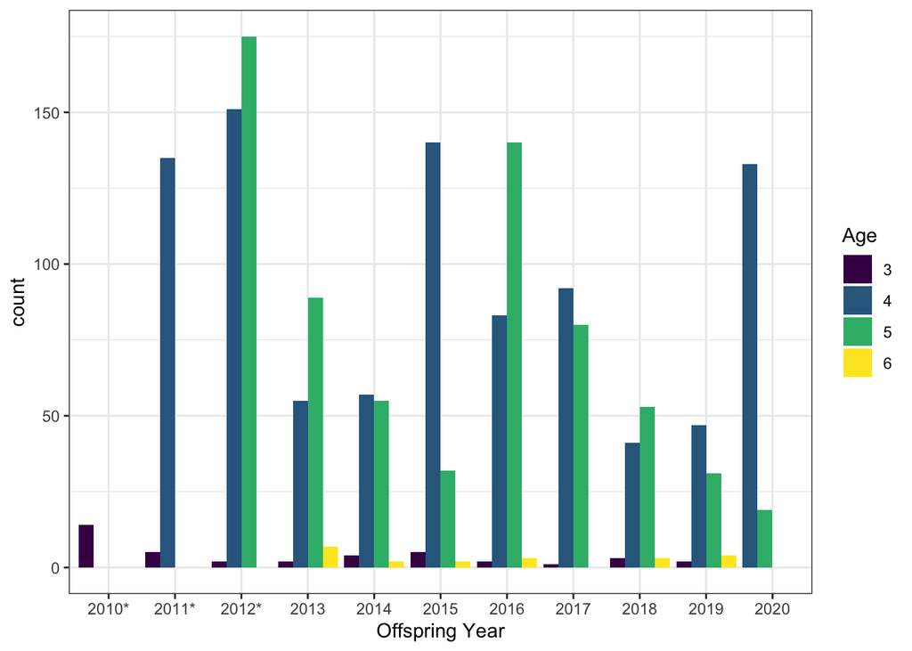

```r
aam_data <- pedigree_meta %>%
  mutate(parent_year = (coalesce(father_year, mother_year))) %>%
  filter(!(is.na(parent_year))) %>%
  mutate(age = as.numeric(offspring_year) - as.numeric(parent_year)) %>%
  mutate(age = as.factor(age), offspring_year = as.factor(offspring_year))


ggplot(data = aam_data) +
  geom_bar(aes(offspring_year, fill = age), position = position_dodge(preserve = 'single'))+scale_fill_viridis_d(name = "Age")+scale_colour_viridis_d(name = "Age")+theme_bw()+xlab("Offspring Year")+scale_x_discrete(labels = c("2010*", "2011*", "2012*", "2013", "2014", "2015", "2016", "2017", "2018", "2019", "2020"))
```

**Figure N1** Number of age 3, 4, 5 and 6 individuals in each offspring year.  
* note earliest parent year in dataset is 2007, so only offpsring years from 2013 and later could possibly have all offspring ages

**Averages**  
Finally let’s produce a summary table of age structure, averaged across all years where we can assign ages for all offspring (2013 - 2020). This will come in handy later.

```r
kable(aam_data %>%
  filter(!(offspring_year %in% c("2010" ,"2011", "2012"))) %>%
  count(age) %>%
  summarise(age = age, n = n, proportion = n / sum(n)), caption = "Table N10: Mean Age Structure", align = "c", digits = 3,) %>%
kable_classic(full_width = F, html_font = "Arial" )
```

Table N10: Mean Age Structure

| age | n | proportion |
| --- | --- | --- |
| 3 | 19 | 0.016 |
| 4 | 648 | 0.546 |
| 5 | 499 | 0.420 |
| 6 | 21 | 0.018 |

**Table N10:** Mean age structure of returning NOR offspring from 2013-2020. This includes all years we have the data to assign to parents in 3, 4, 5, and 6 years prior.

Age 6 offspring compose just ~2% of TLF, but age 5 offspring compose 42%. So we can probably comfortably use our dataset to describe TLF for 2007 - 2015 parent years. Fitness of parents in our pedigree (up to 2020 offspring year) is likely to strongly underestimate 2016 and 2017 TLF.

## Assignments, by Offspring Year and Parent Type/Year

Here we summarise assignment of offspring to different parent types and year.

Each below table represents a single pair of offspring and parent years. The type of offspring is listed in the first column and the results are split between parent types along the remaining columns (e.g. same format as table 3 from NSNT report)

When the “type” of parent varies between two parents, the female parent type is listed first. For example, if an offspring is assigned to a reintroduced mother and carcass father, the column would be called “reintro/carcass.”

Note that some tables are missing e.g. 2017 offspring assigned to 2011 parents. This is because there are no such assignments in the pedigree, or only a single assigment.

```r
# the format of the table in the report is difficult to produce in r
# let's not change the format of the table, instead we'll write some helper functions for filling it out

#let's add a column for the type of assignment, and one for combined types
pedigree_meta %<>%
  mutate(assn_type = case_when((mother == "none" & father == "none") ~ "none",
                               (mother == "none" & father != "none") ~ "male_only",
                               (mother != "none" & father == "none") ~ "female_only",
                               (mother != "none" & father != "none") ~ "pair",)) %>%
  mutate(parent_type = case_when((father_type == mother_type) ~ father_type,
                                 (is.na(father_type) & !(is.na(mother_type))) ~ mother_type,
                                  (is.na(mother_type) & !(is.na(father_type))) ~ father_type,
                                   (father_type != mother_type) ~ paste(mother_type, father_type, sep = "/")))

# function
t4_helper <- function(p_year, off_year){pedigree_meta %>%
  filter(offspring_year == off_year) %>%
  filter(parent_year == p_year) %>%
  mutate(parent_type = as.factor(parent_type)) %>%
  select(offspring_type, parent_type, assn_type) %>%
  tbl_strata(
    strata = parent_type,
    .tbl_fun = ~ .x %>%
      tbl_summary( by = assn_type, percent = NULL)
  ) %>%
  modify_caption(paste(paste("parent year: ", p_year), paste("offspring year: ", off_year), sep = "  ,")) %>%
  as_kable_extra() %>%
  kable_classic(full_width = F, html_font = "Arial")
}
```

Note that we’re only presenting these tables for the new offspring years.

```r
#t4 helper function example

t4_helper("2010", "2016")
```

parent year: 2010 ,offspring year: 2016

| Characteristic | cougar_trap male_only, N = 1 | hatchery_outplant female_only, N = 2 |
| --- | --- | --- |
| offspring_type |  |  |
| sgs | 1 (100%) | 2 (100%) |

<sup>1</sup> n (%)

```r
t4_helper("2011", "2016")
```

parent year: 2011 ,offspring year: 2016

| Characteristic | cougar_trap female_only, N = 10 | cougar_trap male_only, N = 15 | cougar_trap pair, N = 31 | cougar_trap/hatchery_outplant pair, N = 7 | hatchery_outplant female_only, N = 15 | hatchery_outplant male_only, N = 8 | hatchery_outplant pair, N = 10 | hatchery_outplant/cougar_trap pair, N = 44 |
| --- | --- | --- | --- | --- | --- | --- | --- | --- |
| offspring_type |  |  |  |  |  |  |  |  |
| cougar_trap | 10 (100%) | 14 (93%) | 30 (97%) | 7 (100%) | 14 (93%) | 7 (88%) | 10 (100%) | 42 (95%) |
| sgs | 0 (0%) | 1 (6.7%) | 1 (3.2%) |  | 1 (6.7%) | 1 (12%) | 0 (0%) | 2 (4.5%) |

<sup>1</sup> n (%)

```r
t4_helper("2012", "2016")
```

parent year: 2012 ,offspring year: 2016

| Characteristic | cougar_trap female_only, N = 4 | cougar_trap male_only, N = 7 | cougar_trap pair, N = 18 | cougar_trap/hatchery_outplant pair, N = 17 | hatchery_outplant female_only, N = 1 | hatchery_outplant male_only, N = 3 | hatchery_outplant pair, N = 3 | hatchery_outplant/cougar_trap pair, N = 30 |
| --- | --- | --- | --- | --- | --- | --- | --- | --- |
| offspring_type |  |  |  |  |  |  |  |  |
| cougar_trap | 2 (50%) | 6 (86%) | 17 (94%) | 17 (100%) | 1 (100%) | 3 (100%) | 3 (100%) | 29 (97%) |
| sgs | 2 (50%) | 1 (14%) | 1 (5.6%) |  |  |  |  | 1 (3.3%) |

<sup>1</sup> n (%)

```r
t4_helper("2013", "2016")
```

parent year: 2013 ,offspring year: 2016

| Characteristic | cougar_trap male_only, N = 1 | hatchery_outplant male_only, N = 1 |
| --- | --- | --- |
| offspring_type |  |  |
| sgs | 1 (100%) | 1 (100%) |

<sup>1</sup> n (%)

```r
# t4_helper("2011", "2017") none so this breaks
t4_helper("2012", "2017")
```

parent year: 2012 ,offspring year: 2017

| Characteristic | cougar_trap female_only, N = 8 | cougar_trap male_only, N = 14 | cougar_trap pair, N = 24 | cougar_trap/hatchery_outplant pair, N = 4 | hatchery_outplant female_only, N = 5 | hatchery_outplant male_only, N = 3 | hatchery_outplant pair, N = 2 | hatchery_outplant/cougar_trap pair, N = 20 |
| --- | --- | --- | --- | --- | --- | --- | --- | --- |
| offspring_type |  |  |  |  |  |  |  |  |
| cougar_trap | 8 (100%) | 12 (86%) | 23 (96%) | 4 (100%) | 5 (100%) | 3 (100%) | 2 (100%) | 20 (100%) |
| sgs | 0 (0%) | 2 (14%) | 1 (4.2%) |  |  |  |  |  |

<sup>1</sup> n (%)

```r
t4_helper("2013", "2017")
```

parent year: 2013 ,offspring year: 2017

| Characteristic | cougar_trap female_only, N = 9 | cougar_trap male_only, N = 7 | cougar_trap pair, N = 15 | cougar_trap/hatchery_outplant pair, N = 9 | hatchery_outplant female_only, N = 14 | hatchery_outplant male_only, N = 8 | hatchery_outplant pair, N = 15 | hatchery_outplant/cougar_trap pair, N = 15 |
| --- | --- | --- | --- | --- | --- | --- | --- | --- |
| offspring_type |  |  |  |  |  |  |  |  |
| cougar_trap | 9 (100%) | 7 (100%) | 15 (100%) | 9 (100%) | 14 (100%) | 8 (100%) | 15 (100%) | 14 (93%) |
| sgs |  |  |  |  |  |  |  | 1 (6.7%) |

<sup>1</sup> n (%)

```r
# t4_helper("2014", "2017") only one so this breaks

t4_helper("2012", "2018")
```

parent year: 2012 ,offspring year: 2018

| Characteristic | cougar_trap male_only, N = 1 | hatchery_outplant male_only, N = 1 | hatchery_outplant/cougar_trap pair, N = 1 |
| --- | --- | --- | --- |
| offspring_type |  |  |  |
| cougar_trap | 1 (100%) | 1 (100%) | 1 (100%) |

<sup>1</sup> n (%)

```r
t4_helper("2013", "2018")
```

parent year: 2013 ,offspring year: 2018

| Characteristic | cougar_trap female_only, N = 1 | cougar_trap male_only, N = 1 | cougar_trap pair, N = 22 | cougar_trap/hatchery_outplant pair, N = 3 | hatchery_outplant female_only, N = 2 | hatchery_outplant male_only, N = 1 | hatchery_outplant pair, N = 5 | hatchery_outplant/cougar_trap pair, N = 18 |
| --- | --- | --- | --- | --- | --- | --- | --- | --- |
| offspring_type |  |  |  |  |  |  |  |  |
| cougar_trap | 0 (0%) | 0 (0%) | 22 (100%) | 2 (67%) | 1 (50%) | 0 (0%) | 5 (100%) | 17 (94%) |
| sgs | 1 (100%) | 1 (100%) | 0 (0%) | 1 (33%) | 1 (50%) | 1 (100%) | 0 (0%) | 1 (5.6%) |

<sup>1</sup> n (%)

```r
t4_helper("2014", "2018")
```

parent year: 2014 ,offspring year: 2018

| Characteristic | cougar_trap female_only, N = 1 | cougar_trap male_only, N = 1 | cougar_trap pair, N = 6 | hatchery_outplant female_only, N = 3 | hatchery_outplant male_only, N = 5 | hatchery_outplant pair, N = 15 | hatchery_outplant/cougar_trap pair, N = 10 |
| --- | --- | --- | --- | --- | --- | --- | --- |
| offspring_type |  |  |  |  |  |  |  |
| cougar_trap | 1 (100%) | 1 (100%) | 6 (100%) | 3 (100%) | 5 (100%) | 15 (100%) | 9 (90%) |
| sgs |  |  |  |  |  |  | 1 (10%) |

<sup>1</sup> n (%)

```r
t4_helper("2015", "2018")
```

parent year: 2015 ,offspring year: 2018

| Characteristic | cougar_trap male_only, N = 1 | hatchery_outplant female_only, N = 1 | hatchery_outplant male_only, N = 1 |
| --- | --- | --- | --- |
| offspring_type |  |  |  |
| cougar_trap | 1 (100%) | 0 (0%) | 1 (100%) |
| sgs |  | 1 (100%) | 0 (0%) |

<sup>1</sup> n (%)

```r
t4_helper("2013", "2019")
```

parent year: 2013 ,offspring year: 2019

| Characteristic | cougar_trap male_only, N = 2 | hatchery_outplant male_only, N = 2 |
| --- | --- | --- |
| offspring_type |  |  |
| sgs | 2 (100%) | 1 (50%) |
| cougar_trap |  | 1 (50%) |

<sup>1</sup> n (%)

```r
t4_helper("2014", "2019")
```

parent year: 2014 ,offspring year: 2019

| Characteristic | cougar_trap male_only, N = 2 | cougar_trap pair, N = 1 | cougar_trap/hatchery_outplant pair, N = 5 | hatchery_outplant female_only, N = 4 | hatchery_outplant male_only, N = 4 | hatchery_outplant pair, N = 7 | hatchery_outplant/cougar_trap pair, N = 8 |
| --- | --- | --- | --- | --- | --- | --- | --- |
| offspring_type |  |  |  |  |  |  |  |
| cougar_trap | 2 (100%) | 1 (100%) | 5 (100%) | 4 (100%) | 4 (100%) | 7 (100%) | 8 (100%) |

<sup>1</sup> n (%)

```r
t4_helper("2015", "2019")
```

parent year: 2015 ,offspring year: 2019

| Characteristic | cougar_trap pair, N = 4 | cougar_trap/hatchery_outplant pair, N = 6 | hatchery_outplant female_only, N = 7 | hatchery_outplant male_only, N = 2 | hatchery_outplant pair, N = 16 | hatchery_outplant/cougar_trap pair, N = 12 |
| --- | --- | --- | --- | --- | --- | --- |
| offspring_type |  |  |  |  |  |  |
| cougar_trap | 4 (100%) | 6 (100%) | 7 (100%) | 1 (50%) | 16 (100%) | 12 (100%) |
| sgs |  |  | 0 (0%) | 1 (50%) | 0 (0%) |  |

<sup>1</sup> n (%)

```r
t4_helper("2016", "2019")
```

parent year: 2016 ,offspring year: 2019

| Characteristic | cougar_trap male_only, N = 1 | hatchery_outplant female_only, N = 1 |
| --- | --- | --- |
| offspring_type |  |  |
| cougar_trap | 1 (100%) | 1 (100%) |

<sup>1</sup> n (%)

```r
# t4_helper("2014", "2020") none so this breaks
t4_helper("2015", "2020")
```

parent year: 2015 ,offspring year: 2020

| Characteristic | cougar_trap male_only, N = 1 | cougar_trap pair, N = 4 | cougar_trap/hatchery_outplant pair, N = 1 | hatchery_outplant pair, N = 6 | hatchery_outplant/cougar_trap pair, N = 7 |
| --- | --- | --- | --- | --- | --- |
| offspring_type |  |  |  |  |  |
| cougar_trap | 1 (100%) | 4 (100%) | 1 (100%) | 6 (100%) | 7 (100%) |

<sup>1</sup> n (%)

```r
t4_helper("2016", "2020")
```

parent year: 2016 ,offspring year: 2020

| Characteristic | cougar_trap female_only, N = 2 | cougar_trap male_only, N = 7 | cougar_trap pair, N = 14 | cougar_trap/hatchery_outplant pair, N = 12 | hatchery_outplant female_only, N = 6 | hatchery_outplant male_only, N = 2 | hatchery_outplant pair, N = 47 | hatchery_outplant/cougar_trap pair, N = 43 |
| --- | --- | --- | --- | --- | --- | --- | --- | --- |
| offspring_type |  |  |  |  |  |  |  |  |
| cougar_trap | 2 (100%) | 7 (100%) | 14 (100%) | 12 (100%) | 6 (100%) | 2 (100%) | 47 (100%) | 43 (100%) |

<sup>1</sup> n (%)

```r
# t4_helper("2017", "2020") none so this breaks
```

## Recycling

In this section we make the assumption that offspring that do not assign to any candidate parent are not offspring of salmon above the dam, and are instead NOR immigrants (i.e. strays) from the mainstem of SFMK below dam populations.

Under this assumption we can evaluate the efficacy of the recycling or LSDR approach at excluding NOR immigrants from being released above the dam. We exclude offspring year 2010 - 2012, since we do not have all of the potential parents from these offspring years included as candidate parents in our parentage analysis.

### GLM

If we think about this for a while the essential question being asked is:

> On a given day, what is the probability that an NOR individual that arrives at the Cougar trap is not assigned to a parent above the dam?

We term this probability “probability of immigrant”. We can model “probability of immigrant” as the response variable in a binomial GLM, using the explanatory variable julian date, and (optionally) including random effect of year. We are also interested in the effect of sex here. It is covariate that we expect will reduce overdispersion in the model fit because we expect the relationship between straying and date to depend on sex.

We could get a lot more detailed with our modeling here, but let’s attempt to model probability of immigrant as a function of julian day and sex.

First let’s plot make some simple plots.

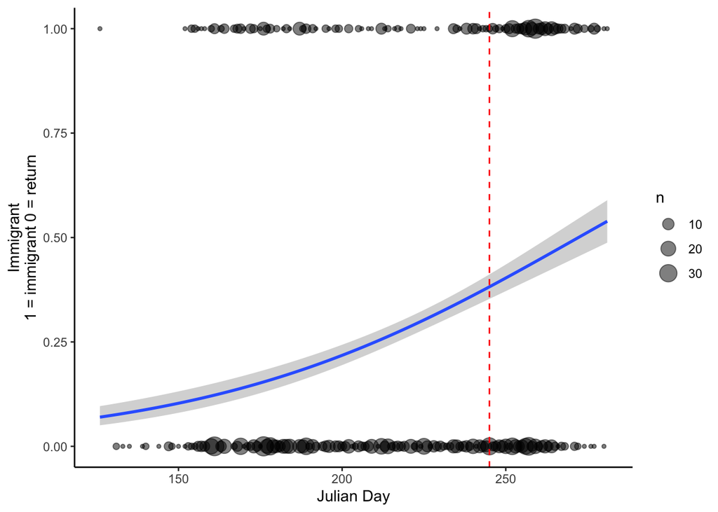

```r
strays <- pedigree_meta %>%
  filter(offspring_year > 2012, offspring_type == "cougar_trap") %>%
  left_join(select(dedup, sample_id, sex), by = c("offspring_sample_id" = "sample_id")) %>%
  mutate(immigrant = case_when(assn_type == "none" ~ "immigrant",
                               TRUE ~ "return"),
         immigrant_i = case_when(assn_type == "none" ~ 1,
                               TRUE ~ 0),
         jday = yday(ymd(offspring_date)))

ggplot(strays, aes(jday, immigrant_i))+geom_count(alpha = 0.5)+geom_smooth(method = "glm", method.args=list(family="binomial"))+theme_classic()+xlab("Julian Day")+ylab("Immigrant\n1 = immigrant 0 = return")+scale_color_viridis_d()+geom_vline(aes(xintercept = 245), linetype = "dashed", color  = "red")
```

**Figure N2:** Julian day vs immigrant count at Cougar Trap. An offspring with no assigned parentage is considered an immigrant (scored as 1), an offpsring with at least one parent is considered a return (scored as zero). Circle size corresponds to number of individuals that day. Offspring years from 2013-2020 are considered. Smoothing curve is a simple binomial glm on the immigrant variable using only the effect of Julian day. Julian day 245 is on or one day from the September 1st cutoff used for LSDR. It is displayed as vertical dashed red line.

Here we see there is a clear relationship between the propensity for an individual to be assigned a parent from above the dam and the day it is sampled at the Cougar Trap.

We also know that the overall assignemnt rate varies from year to year. Let’s see if the relationship between Julian day and the propensity for an immigrant to be sampled at the Cougar trap depends on year.

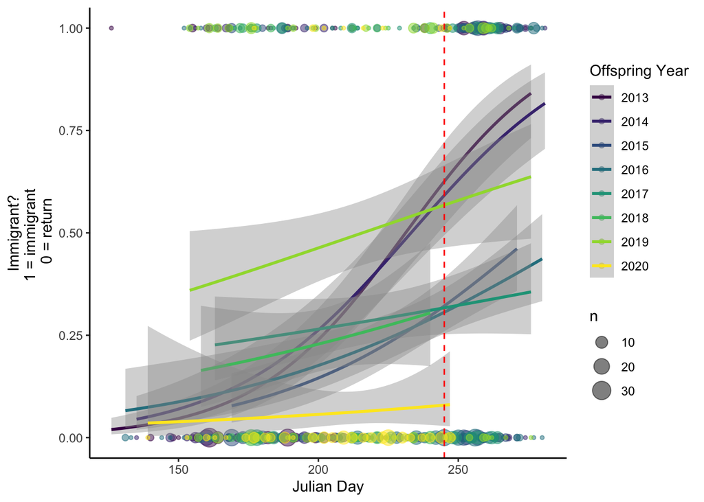

```r
ggplot(strays, aes(jday, immigrant_i, color = as.factor(offspring_year)))+geom_count(alpha = 0.5)+geom_smooth(method = "glm", method.args=list(family="binomial"))+theme_classic()+xlab("Julian Day")+ylab("Immigrant?\n1 = immigrant \n 0 = return")+scale_color_viridis_d(name = "Offspring Year")+geom_vline(aes(xintercept = 245), linetype = "dashed", color  = "red")
```

**Figure N3:** Julian day vs immigrant count at Cougar Trap, by offspring year. An offspring with no assigned parentage is considered an immigrant (scored as 1), an offpsring with at least one parent is considered a return (scored as zero). Circle size corresponds to number of individuals that day. Offspring years from 2013-2020 are considered. Smoothing curve is a simple binomial glm on the immigrant variable using only the effect of Julian day. Julian day 245 is on or one day from the September 1st cutoff used for LSDR. It is displayed as vertical dashed red line.

Yes, while the general trend is the same, there is some variation among year. 2020 saw almost no immigrants.

**Fit GLM**  
Now let’s fit a smple glm using sex, julian day and their interaction

```r
strays %<>%
  mutate(immigrant = as.factor(immigrant))

strays %<>%
  mutate(offspring_year = as.factor(offspring_year))

stray_glm <- glm( immigrant ~ jday + sex +jday*sex , family = binomial, data = strays)
summary(stray_glm)
```

```
##
## Call:
## glm(formula = immigrant ~ jday + sex + jday * sex, family = binomial,
##     data = strays)
##
## Deviance Residuals:
##     Min       1Q   Median       3Q      Max
## -2.2099  -1.1796   0.6045   0.8818   1.3296
##
## Coefficients:
##              Estimate Std. Error z value Pr(>|z|)
## (Intercept)  3.983473   0.587581   6.779 1.21e-11 ***
## jday        -0.012957   0.002639  -4.910 9.12e-07 ***
## sexM         1.203238   0.777571   1.547   0.1218
## jday:sexM   -0.006820   0.003422  -1.993   0.0463 *
## ---
## Signif. codes:  0 '***' 0.001 '**' 0.01 '*' 0.05 '.' 0.1 ' ' 1
##
## (Dispersion parameter for binomial family taken to be 1)
##
##     Null deviance: 1969.6  on 1625  degrees of freedom
## Residual deviance: 1830.2  on 1622  degrees of freedom
##   (3 observations deleted due to missingness)
## AIC: 1838.2
##
## Number of Fisher Scoring iterations: 4
```

```r
drop1(stray_glm, test = "Chisq")
```

|  | Df | Deviance | AIC | LRT | Pr(>Chi) |
| --- | --- | --- | --- | --- | --- |
|  | NA | 1830.174 | 1838.174 | NA | NA |
| jday:sex | 1 | 1834.129 | 1840.129 | 3.95504 | 0.0467312 |

The interaction between the effect of julian day and sex is only marginally significant (p = 0.046, likelihood ratio test). So let’s drop it and fit again. We will consider both model fits.

```r
stray_glm2 <- glm( immigrant ~ jday + sex , family = binomial, data = strays)
summary(stray_glm2)
```

```
##
## Call:
## glm(formula = immigrant ~ jday + sex, family = binomial, data = strays)
##
## Deviance Residuals:
##     Min       1Q   Median       3Q      Max
## -2.3702  -1.2148   0.6210   0.8902   1.2725
##
## Coefficients:
##             Estimate Std. Error z value Pr(>|z|)
## (Intercept)  4.90413    0.38450  12.754  < 2e-16 ***
## jday        -0.01712    0.00167 -10.254  < 2e-16 ***
## sexM        -0.33036    0.12167  -2.715  0.00662 **
## ---
## Signif. codes:  0 '***' 0.001 '**' 0.01 '*' 0.05 '.' 0.1 ' ' 1
##
## (Dispersion parameter for binomial family taken to be 1)
##
##     Null deviance: 1969.6  on 1625  degrees of freedom
## Residual deviance: 1834.1  on 1623  degrees of freedom
##   (3 observations deleted due to missingness)
## AIC: 1840.1
##
## Number of Fisher Scoring iterations: 4
```

```r
drop1(stray_glm2, test = "Chisq")
```

|  | Df | Deviance | AIC | LRT | Pr(>Chi) |
| --- | --- | --- | --- | --- | --- |
|  | NA | 1834.129 | 1840.129 | NA | NA |
| jday | 1 | 1950.559 | 1954.559 | 116.430196 | 3.826117e-27 |
| sex | 1 | 1841.602 | 1845.602 | 7.473418 | 6.261655e-03 |

When we ignore the interaction, the effect both variables are still strongly significant, both by Wald tests and likelihood ratio tests.

```r
stray_glm2 <- glmer( immigrant ~ jday*sex+ (1|offspring_year) , family = binomial, data = strays)
summary(stray_glm2)
drop1(stray_glm2, test = "Chisq")
```

**GLM Interpretation**  
The response variable is coded with immigrant as the first level and return as the second. Therefore a negative estimated effect of an explanatory variable means that that variable increases the propensity for an immigrant at the trap. (It might be worth releveling the “immigrant” variable factor to make effect estimates and figures consistent with the “probability of immigrant” language used earlier)

So, to interpet the model with the interaction, later in the season there is a significant increase in the proability of immigrants arriving at the trap, and this effect is stronger for males than females. Once you control for julian date, there is no greater propensity for male immigrants to arrive a the trap than for female immigrants.

Let’s also plot this model.

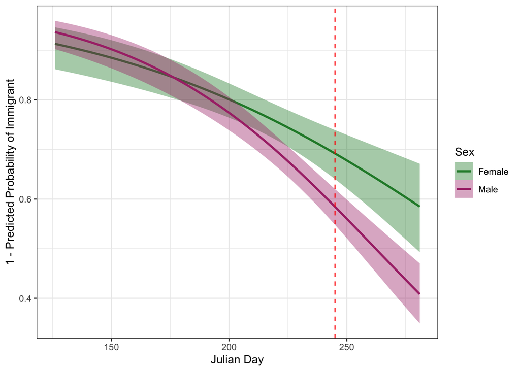

```r
require(effects)

#let's not use the effect package plotting tools and just get the effects

#eff1 <- predictorEffect("sex_ratio_y_l", final_model, focal.levels = seq(-0.4,0.7,by = 0.1))
eff1 <- predictorEffect("jday", stray_glm)
effdf <- as.data.frame(eff1)


ggplot(data = effdf, aes(x = (jday), y = fit, color = sex))+
  geom_line()+geom_smooth( aes(ymin = lower, ymax = upper, fill = sex, colour = sex), stat = "identity") +
  theme_bw()+ylab("1 - Predicted Probability of Immigrant") + scale_color_manual(labels = c("Female", "Male"), name = "Sex", values = c("#228833", "#AA3377")) + scale_fill_manual(labels = c("Female", "Male"), name = "Sex", values = c("#228833", "#AA3377"))+xlab("Julian Day")+geom_vline(aes(xintercept = 245), linetype = "dashed", color  = "red")
```

**Figure N4:** Predicted probability that an individual arriving at Cougar Trap assigns to a parent released above the Dam vs Julian Day. Vertical red dashed line corresponds to Julian Day 245, on or near September 1st.

**Summary**  
This is somewhat preliminary. We still should do model validation and think about how to incorporate other covariates or whether or not to include random effect of year.

With respect to the broader question, the efficacy of LSDR and or recycling, it seems that relatively few (<20%) of NOR salmon sampled at the trap before around July 1st (Julian day 182, most years) are immigrants. By September 1st, the date previously used as the cutoff for LSDR, about 30% of females and about 40% of males are predicted to be immigrants. However, it should be noted that these results are highly variable among years.

# Fitness

In this section, we calculate the number of offspring assigned to parents from the pedigree and calculate summary statistics.

## Data Prep

Let’s get our first parent-focused dataframe together. This will have one row for each unqiue candidate parent as well as the number of offspring assigned to it in the pedigree.

```r
#first let's get a dataframe that can be easily used to calculate parent level information
# all candidate parents, the number of time they appear in the pedigree and their metadata

parents <- dedup %>%
  filter(cand_parent == TRUE)

father_counts <- pedigree %>%
  group_by(father) %>%
  count() %>%
  rename(parent = father)

mother_counts <- pedigree %>%
  group_by(mother) %>%
  count() %>%
  rename(parent = mother)

parent_counts <- bind_rows(mother_counts, father_counts)
rm(mother_counts)
rm(father_counts)

parents %<>%
  left_join(parent_counts, by = c("sample_id" = "parent")) %>%
  rename(tlf = n) %>%
  mutate(tlf = replace_na(tlf, 0))
```

## TLF Results

Let’s put together some tables of fitness averages by groups.

Note that TLF only applies when we have ages 3, 4, 5 and 6 offspring for a year. However, our AAM results suggests that fitness using only ages 3, 4 and 5 offspring only slightly underestimates TLF (98% of returning offspring are ages 3, 4 or 5), so using returns from 2010 to 2020, we have TLF estimates for 2007-2014 parent years, a good approximation for 2015, and only partial fitness estimates for 2016 and 2017. These caveats are noted in all subsequent tables and figures

```r
# average fitness, by parent year
kable(parents %>%
        filter(year < 2018) %>%
  group_by(year) %>%
  summarise(N = n(), mean_tlf = mean(tlf), sd_tlf = sd(tlf), range = paste(min(tlf), " -  ", max(tlf))) %>%
    mutate(year = as.character(year),
      year = case_when(year == 2015 ~ "2015*",
                       year == 2016 ~ "2016**",
                       year == 2017 ~ "2017**",
                            TRUE ~ year)), align = "c", caption = "Table N11: Total Lifetime Fitness by Parent Year", digits = 2) %>%
  kable_classic(full_width = F, html_font = "Arial")
```

Table N11: Total Lifetime Fitness by Parent Year

| year | N | mean_tlf | sd_tlf | range |
| --- | --- | --- | --- | --- |
| 2007 | 745 | 0.79 | 1.53 | 0 - 17 |
| 2008 | 873 | 0.53 | 1.20 | 0 - 12 |
| 2009 | 1383 | 0.14 | 0.44 | 0 - 4 |
| 2010 | 747 | 0.22 | 0.63 | 0 - 6 |
| 2011 | 725 | 0.64 | 1.42 | 0 - 9 |
| 2012 | 947 | 0.31 | 0.68 | 0 - 5 |
| 2013 | 627 | 0.40 | 0.92 | 0 - 8 |
| 2014 | 652 | 0.19 | 0.55 | 0 - 4 |
| 2015* | 754 | 0.17 | 0.48 | 0 - 6 |
| 2016** | 705 | 0.36 | 0.80 | 0 - 8 |
| 2017** | 605 | 0.00 | 0.00 | 0 - 0 |

**Table N11:** TLF per parent year.  
* Note that 2015 estimates do not include potential year 6 offspring. However we expect these offspring to contribute very little to TLF (~2%)  
** Note that 2016 and 2017 offspring do not include potential year 5 and 6 offspring, and potential year 4 5 and 6 offspring, which are expected to substantially contribute to TLF for these parents years

```r
# average fitness, by parent year
kable(parents %>%
        filter(year < 2018, type %in% c("cougar_trap", "hatchery_outplant")) %>%
  group_by(year, type) %>%
  summarise(N = n(), mean_tlf = mean(tlf), sd_tlf = sd(tlf), range = paste(min(tlf), " -  ", max(tlf))) %>%
        mutate(year = as.character(year),
      year = case_when(year == 2015 ~ "2015*",
                       year == 2016 ~ "2016**",
                       year == 2017 ~ "2017**",
                            TRUE ~ year),
      type = case_when(type == "hatchery_outplant" ~ "hatchery",
                       type == "cougar_trap" ~ "cougar trap")) %>%
    rename(source = type,), align = "c", caption = "Table N12: Total Lifetime Fitness by Parent Year and Source", digits = 2) %>%
  kable_classic(full_width = F, html_font = "Arial")
```

Table N12: Total Lifetime Fitness by Parent Year and Source

| year | source | N | mean_tlf | sd_tlf | range |
| --- | --- | --- | --- | --- | --- |
| 2007 | hatchery | 745 | 0.79 | 1.53 | 0 - 17 |
| 2008 | hatchery | 873 | 0.53 | 1.20 | 0 - 12 |
| 2009 | hatchery | 1383 | 0.14 | 0.44 | 0 - 4 |
| 2010 | cougar trap | 251 | 0.26 | 0.65 | 0 - 4 |
| 2010 | hatchery | 496 | 0.19 | 0.63 | 0 - 6 |
| 2011 | cougar trap | 385 | 0.74 | 1.54 | 0 - 9 |
| 2011 | hatchery | 340 | 0.54 | 1.26 | 0 - 9 |
| 2012 | cougar trap | 517 | 0.38 | 0.77 | 0 - 5 |
| 2012 | hatchery | 430 | 0.22 | 0.53 | 0 - 3 |
| 2013 | cougar trap | 187 | 0.75 | 1.30 | 0 - 8 |
| 2013 | hatchery | 440 | 0.26 | 0.65 | 0 - 5 |
| 2014 | cougar trap | 153 | 0.27 | 0.74 | 0 - 4 |
| 2014 | hatchery | 486 | 0.17 | 0.48 | 0 - 3 |
| 2015* | cougar trap | 154 | 0.29 | 0.69 | 0 - 6 |
| 2015* | hatchery | 600 | 0.14 | 0.41 | 0 - 4 |
| 2016** | cougar trap | 242 | 0.38 | 0.88 | 0 - 8 |
| 2016** | hatchery | 459 | 0.34 | 0.75 | 0 - 6 |
| 2017** | cougar trap | 157 | 0.00 | 0.00 | 0 - 0 |
| 2017** | hatchery | 448 | 0.00 | 0.00 | 0 - 0 |

**Table N12:** TLF per parent year, and parent source. Parent source refers to either*** individuals trapped at the Cougar Trap and released above the dam (“Cougar Trap”, NOR and HOR) or individuals trapped at McKEnzie or Leaburg Hatcheries and released above the dam (“Hatchery”, HOR)  
* Note that 2015 estimates do not include potential year 6 offspring. However we expect these offspring to contribute very little to TLF (~2%)  
** Note that 2016 and 2017 offspring do not include potential year 5 and 6 offspring, and potential year 4 5 and 6 offspring, which are expected to substantially contribute to TLF for these parents years  
*** Note that there are 5 individuals sampled during spawning ground surveys above the dam and 12 precocial males sampled above the dam that were included as candidate parents. None had an offspring assigned to them and they are not presented in this table

```r
# average fitness, by parent year
kable(parents %>%
        filter(year < 2018, type %in% c("cougar_trap", "hatchery_outplant")) %>%
  group_by(year, type, sex) %>%
  summarise(N = n(), mean_tlf = mean(tlf), sd_tlf = sd(tlf), range = paste(min(tlf), " -  ", max(tlf))) %>%
        mutate(year = as.character(year),
      year = case_when(year == 2015 ~ "2015*",
                       year == 2016 ~ "2016**",
                       year == 2017 ~ "2017**",
                            TRUE ~ year),
      type = case_when(type == "hatchery_outplant" ~ "hatchery",
                       type == "cougar_trap" ~ "cougar trap")) %>%
    rename(source = type,), align = "c", caption = "Table N13: Total Lifetime Fitness by Parent Year, Source and Sex", digits = 2) %>%
  kable_classic(full_width = F, html_font = "Arial")
```

Table N13: Total Lifetime Fitness by Parent Year, Source and Sex

| year | source | sex | N | mean_tlf | sd_tlf | range |
| --- | --- | --- | --- | --- | --- | --- |
| 2007 | hatchery | F | 318 | 0.89 | 1.49 | 0 - 11 |
| 2007 | hatchery | M | 427 | 0.72 | 1.56 | 0 - 17 |
| 2008 | hatchery | F | 288 | 0.80 | 1.46 | 0 - 12 |
| 2008 | hatchery | M | 585 | 0.40 | 1.03 | 0 - 9 |
| 2009 | hatchery | F | 603 | 0.16 | 0.47 | 0 - 4 |
| 2009 | hatchery | M | 780 | 0.13 | 0.43 | 0 - 3 |
| 2010 | cougar trap | F | 62 | 0.23 | 0.61 | 0 - 3 |
| 2010 | cougar trap | M | 189 | 0.27 | 0.66 | 0 - 4 |
| 2010 | hatchery | F | 201 | 0.29 | 0.74 | 0 - 5 |
| 2010 | hatchery | M | 295 | 0.13 | 0.53 | 0 - 6 |
| 2011 | cougar trap | F | 150 | 0.66 | 1.30 | 0 - 7 |
| 2011 | cougar trap | M | 235 | 0.79 | 1.67 | 0 - 9 |
| 2011 | hatchery | F | 170 | 0.78 | 1.59 | 0 - 9 |
| 2011 | hatchery | M | 170 | 0.29 | 0.73 | 0 - 4 |
| 2012 | cougar trap | F | 191 | 0.40 | 0.76 | 0 - 5 |
| 2012 | cougar trap | M | 326 | 0.36 | 0.78 | 0 - 5 |
| 2012 | hatchery | F | 248 | 0.25 | 0.58 | 0 - 3 |
| 2012 | hatchery | M | 182 | 0.18 | 0.46 | 0 - 2 |
| 2013 | cougar trap | F | 86 | 0.69 | 1.20 | 0 - 6 |
| 2013 | cougar trap | M | 101 | 0.80 | 1.38 | 0 - 8 |
| 2013 | hatchery | F | 239 | 0.29 | 0.71 | 0 - 5 |
| 2013 | hatchery | M | 201 | 0.22 | 0.57 | 0 - 3 |
| 2014 | cougar trap | F | 59 | 0.24 | 0.75 | 0 - 4 |
| 2014 | cougar trap | M | 94 | 0.30 | 0.73 | 0 - 3 |
| 2014 | hatchery | F | 327 | 0.14 | 0.45 | 0 - 3 |
| 2014 | hatchery | M | 159 | 0.23 | 0.54 | 0 - 3 |
| 2015* | cougar trap | F | 53 | 0.28 | 0.91 | 0 - 6 |
| 2015* | cougar trap | M | 101 | 0.29 | 0.55 | 0 - 3 |
| 2015* | hatchery | F | 412 | 0.12 | 0.35 | 0 - 2 |
| 2015* | hatchery | M | 188 | 0.17 | 0.51 | 0 - 4 |
| 2016** | cougar trap | F | 86 | 0.33 | 0.58 | 0 - 2 |
| 2016** | cougar trap | M | 156 | 0.42 | 1.00 | 0 - 8 |
| 2016** | hatchery | F | 315 | 0.31 | 0.66 | 0 - 5 |
| 2016** | hatchery | M | 144 | 0.42 | 0.93 | 0 - 6 |
| 2017** | cougar trap | F | 45 | 0.00 | 0.00 | 0 - 0 |
| 2017** | cougar trap | M | 112 | 0.00 | 0.00 | 0 - 0 |
| 2017** | hatchery | F | 325 | 0.00 | 0.00 | 0 - 0 |
| 2017** | hatchery | M | 123 | 0.00 | 0.00 | 0 - 0 |

**Table N13:** TLF per parent year, parent source and sex. Parent source refers to either*** individuals trapped at the Cougar Trap and released above the dam (“Cougar Trap”, NOR and HOR) or individuals trapped at McKEnzie or Leaburg Hatcheries and released above the dam (“Hatchery”, HOR)  
* Note that 2015 estimates do not include potential year 6 offspring. However we expect these offspring to contribute very little to TLF (~2%)  
** Note that 2016 and 2017 offspring do not include potential year 5 and 6 offspring, and potential year 4 5 and 6 offspring, which are expected to substantially contribute to TLF for these parents years  
*** Note that there are 5 individuals sampled during spawning ground surveys above the dam and 12 precocial males sampled above the dam that were included as candidate parents. None had an offspring assigned to them and they are not presented in this table

```r
# average fitness, by parent year
kable(parents %>%
        filter(year < 2018, type %in% c("cougar_trap", "hatchery_outplant")) %>%
  group_by(year, origin, sex) %>%
  summarise(N = n(), mean_tlf = mean(tlf), sd_tlf = sd(tlf), range = paste(min(tlf), " -  ", max(tlf))) %>%
        mutate(year = as.character(year),
      year = case_when(year == 2015 ~ "2015*",
                       year == 2016 ~ "2016**",
                       year == 2017 ~ "2017**",
                            TRUE ~ year)
      ) %>%
    pivot_wider(id_cols = c(year, sex), names_from = origin, values_from = c(N, mean_tlf, sd_tlf, range)), align = "c", caption = "Table N13c: Total Lifetime Fitness by Parent Year, Origin, and Sex", digits = 2) %>%
  kable_classic(full_width = F, html_font = "Arial")
```

Table N13c: Total Lifetime Fitness by Parent Year, Origin, and Sex

| year | sex | N_HOR | N_NOR | N_NA | mean_tlf_HOR | mean_tlf_NOR | mean_tlf_NA | sd_tlf_HOR | sd_tlf_NOR | sd_tlf_NA | range_HOR | range_NOR | range_NA |
| --- | --- | --- | --- | --- | --- | --- | --- | --- | --- | --- | --- | --- | --- |
| 2007 | F | 318 |  |  | 0.89 |  |  | 1.49 |  |  | 0 - 11 |  |  |
| 2007 | M | 427 |  |  | 0.72 |  |  | 1.56 |  |  | 0 - 17 |  |  |
| 2008 | F | 288 |  |  | 0.80 |  |  | 1.46 |  |  | 0 - 12 |  |  |
| 2008 | M | 585 |  |  | 0.40 |  |  | 1.03 |  |  | 0 - 9 |  |  |
| 2009 | F | 603 |  |  | 0.16 |  |  | 0.47 |  |  | 0 - 4 |  |  |
| 2009 | M | 780 |  |  | 0.13 |  |  | 0.43 |  |  | 0 - 3 |  |  |
| 2010 | F | 206 | 57 |  | 0.29 | 0.25 |  | 0.73 | 0.63 |  | 0 - 5 | 0 - 3 |  |
| 2010 | M | 320 | 164 |  | 0.13 | 0.29 |  | 0.52 | 0.69 |  | 0 - 6 | 0 - 4 |  |
| 2011 | F | 176 | 144 |  | 0.76 | 0.68 |  | 1.57 | 1.33 |  | 0 - 9 | 0 - 7 |  |
| 2011 | M | 193 | 212 |  | 0.27 | 0.86 |  | 0.69 | 1.74 |  | 0 - 4 | 0 - 9 |  |
| 2012 | F | 256 | 183 |  | 0.25 | 0.41 |  | 0.58 | 0.77 |  | 0 - 3 | 0 - 5 |  |
| 2012 | M | 191 | 317 |  | 0.18 | 0.37 |  | 0.46 | 0.78 |  | 0 - 2 | 0 - 5 |  |
| 2013 | F | 248 | 77 |  | 0.28 | 0.75 |  | 0.70 | 1.25 |  | 0 - 5 | 0 - 6 |  |
| 2013 | M | 207 | 95 |  | 0.21 | 0.85 |  | 0.56 | 1.41 |  | 0 - 3 | 0 - 8 |  |
| 2014 | F | 334 | 52 |  | 0.14 | 0.27 |  | 0.45 | 0.79 |  | 0 - 3 | 0 - 4 |  |
| 2014 | M | 172 | 80 | 1 | 0.23 | 0.30 | 0 | 0.57 | 0.72 |  | 0 - 3 | 0 - 3 | 0 - 0 |
| 2015* | F | 417 | 48 |  | 0.12 | 0.31 |  | 0.35 | 0.95 |  | 0 - 2 | 0 - 6 |  |
| 2015* | M | 202 | 87 |  | 0.17 | 0.31 |  | 0.50 | 0.58 |  | 0 - 4 | 0 - 3 |  |
| 2016** | F | 336 | 64 | 1 | 0.30 | 0.39 | 0 | 0.64 | 0.63 |  | 0 - 5 | 0 - 2 | 0 - 0 |
| 2016** | M | 193 | 107 |  | 0.35 | 0.54 |  | 0.84 | 1.16 |  | 0 - 6 | 0 - 8 |  |
| 2017** | F | 328 | 42 |  | 0.00 | 0.00 |  | 0.00 | 0.00 |  | 0 - 0 | 0 - 0 |  |
| 2017** | M | 125 | 109 | 1 | 0.00 | 0.00 | 0 | 0.00 | 0.00 |  | 0 - 0 | 0 - 0 | 0 - 0 |

**Table N13b:** TLF per parent year, origin and sex. Parent source refers to either*** individuals trapped at the Cougar Trap and released above the dam (“Cougar Trap”, NOR and HOR) or individuals trapped at McKEnzie or Leaburg Hatcheries and released above the dam (“Hatchery”, HOR)  
* Note that 2015 estimates do not include potential year 6 offspring. However we expect these offspring to contribute very little to TLF (~2%)  
** Note that 2016 and 2017 offspring do not include potential year 5 and 6 offspring, and potential year 4 5 and 6 offspring, which are expected to substantially contribute to TLF for these parents years  
*** Note that there are 5 individuals sampled during spawning ground surveys above the dam and 12 precocial males sampled above the dam that were included as candidate parents. None had an offspring assigned to them and they are not presented in this table

```r
# average fitness, by parent year
kable(parents %>%
        filter(year < 2018, type %in% c("cougar_trap", "hatchery_outplant")) %>%
  group_by(year, type, origin, sex) %>%
  summarise(N = n(), mean_tlf = mean(tlf), sd_tlf = sd(tlf), range = paste(min(tlf), " -  ", max(tlf))) %>%
        mutate(year = as.character(year),
      year = case_when(year == 2015 ~ "2015*",
                       year == 2016 ~ "2016**",
                       year == 2017 ~ "2017**",
                            TRUE ~ year),
      type = case_when(type == "hatchery_outplant" ~ "hatchery",
                       type == "cougar_trap" ~ "cougar trap")) %>%
    rename(source = type,), align = "c", caption = "Table N13c: Total Lifetime Fitness by Parent Year, Source Origin, and Sex", digits = 2) %>%
  kable_classic(full_width = F, html_font = "Arial")
```

Table N13c: Total Lifetime Fitness by Parent Year, Source Origin, and Sex

| year | source | origin | sex | N | mean_tlf | sd_tlf | range |
| --- | --- | --- | --- | --- | --- | --- | --- |
| 2007 | hatchery | HOR | F | 318 | 0.89 | 1.49 | 0 - 11 |
| 2007 | hatchery | HOR | M | 427 | 0.72 | 1.56 | 0 - 17 |
| 2008 | hatchery | HOR | F | 288 | 0.80 | 1.46 | 0 - 12 |
| 2008 | hatchery | HOR | M | 585 | 0.40 | 1.03 | 0 - 9 |
| 2009 | hatchery | HOR | F | 603 | 0.16 | 0.47 | 0 - 4 |
| 2009 | hatchery | HOR | M | 780 | 0.13 | 0.43 | 0 - 3 |
| 2010 | cougar trap | HOR | F | 5 | 0.00 | 0.00 | 0 - 0 |
| 2010 | cougar trap | HOR | M | 25 | 0.16 | 0.37 | 0 - 1 |
| 2010 | cougar trap | NOR | F | 57 | 0.25 | 0.63 | 0 - 3 |
| 2010 | cougar trap | NOR | M | 164 | 0.29 | 0.69 | 0 - 4 |
| 2010 | hatchery | HOR | F | 201 | 0.29 | 0.74 | 0 - 5 |
| 2010 | hatchery | HOR | M | 295 | 0.13 | 0.53 | 0 - 6 |
| 2011 | cougar trap | HOR | F | 6 | 0.17 | 0.41 | 0 - 1 |
| 2011 | cougar trap | HOR | M | 23 | 0.13 | 0.34 | 0 - 1 |
| 2011 | cougar trap | NOR | F | 144 | 0.68 | 1.33 | 0 - 7 |
| 2011 | cougar trap | NOR | M | 212 | 0.86 | 1.74 | 0 - 9 |
| 2011 | hatchery | HOR | F | 170 | 0.78 | 1.59 | 0 - 9 |
| 2011 | hatchery | HOR | M | 170 | 0.29 | 0.73 | 0 - 4 |
| 2012 | cougar trap | HOR | F | 8 | 0.25 | 0.46 | 0 - 1 |
| 2012 | cougar trap | HOR | M | 9 | 0.11 | 0.33 | 0 - 1 |
| 2012 | cougar trap | NOR | F | 183 | 0.41 | 0.77 | 0 - 5 |
| 2012 | cougar trap | NOR | M | 317 | 0.37 | 0.78 | 0 - 5 |
| 2012 | hatchery | HOR | F | 248 | 0.25 | 0.58 | 0 - 3 |
| 2012 | hatchery | HOR | M | 182 | 0.18 | 0.46 | 0 - 2 |
| 2013 | cougar trap | HOR | F | 9 | 0.11 | 0.33 | 0 - 1 |
| 2013 | cougar trap | HOR | M | 6 | 0.00 | 0.00 | 0 - 0 |
| 2013 | cougar trap | NOR | F | 77 | 0.75 | 1.25 | 0 - 6 |
| 2013 | cougar trap | NOR | M | 95 | 0.85 | 1.41 | 0 - 8 |
| 2013 | hatchery | HOR | F | 239 | 0.29 | 0.71 | 0 - 5 |
| 2013 | hatchery | HOR | M | 201 | 0.22 | 0.57 | 0 - 3 |
| 2014 | cougar trap | HOR | F | 7 | 0.00 | 0.00 | 0 - 0 |
| 2014 | cougar trap | HOR | M | 13 | 0.31 | 0.85 | 0 - 3 |
| 2014 | cougar trap | NOR | F | 52 | 0.27 | 0.79 | 0 - 4 |
| 2014 | cougar trap | NOR | M | 80 | 0.30 | 0.72 | 0 - 3 |
| 2014 | cougar trap |  | M | 1 | 0.00 |  | 0 - 0 |
| 2014 | hatchery | HOR | F | 327 | 0.14 | 0.45 | 0 - 3 |
| 2014 | hatchery | HOR | M | 159 | 0.23 | 0.54 | 0 - 3 |
| 2015* | cougar trap | HOR | F | 5 | 0.00 | 0.00 | 0 - 0 |
| 2015* | cougar trap | HOR | M | 14 | 0.14 | 0.36 | 0 - 1 |
| 2015* | cougar trap | NOR | F | 48 | 0.31 | 0.95 | 0 - 6 |
| 2015* | cougar trap | NOR | M | 87 | 0.31 | 0.58 | 0 - 3 |
| 2015* | hatchery | HOR | F | 412 | 0.12 | 0.35 | 0 - 2 |
| 2015* | hatchery | HOR | M | 188 | 0.17 | 0.51 | 0 - 4 |
| 2016** | cougar trap | HOR | F | 21 | 0.14 | 0.36 | 0 - 1 |
| 2016** | cougar trap | HOR | M | 49 | 0.14 | 0.41 | 0 - 2 |
| 2016** | cougar trap | NOR | F | 64 | 0.39 | 0.63 | 0 - 2 |
| 2016** | cougar trap | NOR | M | 107 | 0.54 | 1.16 | 0 - 8 |
| 2016** | cougar trap |  | F | 1 | 0.00 |  | 0 - 0 |
| 2016** | hatchery | HOR | F | 315 | 0.31 | 0.66 | 0 - 5 |
| 2016** | hatchery | HOR | M | 144 | 0.42 | 0.93 | 0 - 6 |
| 2017** | cougar trap | HOR | F | 3 | 0.00 | 0.00 | 0 - 0 |
| 2017** | cougar trap | HOR | M | 2 | 0.00 | 0.00 | 0 - 0 |
| 2017** | cougar trap | NOR | F | 42 | 0.00 | 0.00 | 0 - 0 |
| 2017** | cougar trap | NOR | M | 109 | 0.00 | 0.00 | 0 - 0 |
| 2017** | cougar trap |  | M | 1 | 0.00 |  | 0 - 0 |
| 2017** | hatchery | HOR | F | 325 | 0.00 | 0.00 | 0 - 0 |
| 2017** | hatchery | HOR | M | 123 | 0.00 | 0.00 | 0 - 0 |

**Table N13c:** TLF per parent year, parent source, origin and sex. Parent source refers to either*** individuals trapped at the Cougar Trap and released above the dam (“Cougar Trap”, NOR and HOR) or individuals trapped at McKEnzie or Leaburg Hatcheries and released above the dam (“Hatchery”, HOR)  
* Note that 2015 estimates do not include potential year 6 offspring. However we expect these offspring to contribute very little to TLF (~2%)  
** Note that 2016 and 2017 offspring do not include potential year 5 and 6 offspring, and potential year 4 5 and 6 offspring, which are expected to substantially contribute to TLF for these parents years  
*** Note that there are 5 individuals sampled during spawning ground surveys above the dam and 12 precocial males sampled above the dam that were included as candidate parents. None had an offspring assigned to them and they are not presented in this table

Let’s also put together a figure to make any trend easier to identify.

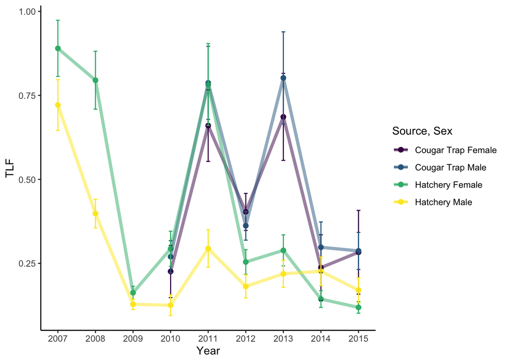

```r
plot_data <- parents %>%
        filter(year < 2016, type %in% c("cougar_trap", "hatchery_outplant")) %>%
  group_by(year, type, sex) %>%
  summarise(N = n(), mean_tlf = mean(tlf), sd_tlf = sd(tlf), se_tlf = sd(tlf)/sqrt(n()), range = paste(min(tlf), " -  ", max(tlf))) %>%
  mutate(type = case_when(type == "hatchery_outplant" ~ "hatchery",
                       type == "cougar_trap" ~ "cougar trap")) %>%
  ungroup() %>%
  unite("type_sex", type, sex)

ggplot(data = plot_data, aes(x = year, y = mean_tlf, color = c(type_sex)))+geom_point(size = 2)+geom_line(size = 1.5, alpha = 0.5)+geom_errorbar(aes(ymin=mean_tlf-se_tlf, ymax=mean_tlf+se_tlf), width=.1)+scale_color_viridis_d(labels = c("Cougar Trap Female", "Cougar Trap Male", "Hatchery Female", "Hatchery Male"), name = "Source, Sex")+theme_classic()+scale_x_continuous(n.breaks = 9)+xlab("Year")+ylab("TLF")
```

**Figure N5:** Mean TLF* and standard error by Candidate Parent Source, Sex and Year. Source refers to either Cougar Trap (includes NOR and HOR) or Hatchery (only HOR).  
* Note that 2015 estimates do not include potential year 6 offspring. However we expect these offspring to contribute very little to TLF (~2%)

From the figure, some trends appear that might be more difficult for some to notice in the tables:  
(1) Parents from Cougar Trap usually ahve higher TLF than parents from the hatchery.  
(2) Male TLF is almost always lower than female TLF among parents outplanted from the hatchery, but not among parents from Cougar trap.  
(3) Changes in fitness from year to year appear correlated between Cougar Trap and the hatchery.